# Social Network Analysis Home Assignment 2

Maria Osipova

due date - 28.05.2018 23:59

# Graph models. Centrality metrics

Please send your reports to hse.ntwks@gmail.com with the subject of of the following structure:  
*[MAGOLEGO SNA 2017] {LastName} {First Name} HA{Number}*

Late submission policy: -1 point per day

Use this file as a template for your report.  
Support your computations with figures and comments. Send ONLY .Rmd versions of your report with datasets for your social network. Anonymize your data if necessary.

```
## R.matlab v3.6.1 (2016-10-19) successfully loaded. See ?R.matlab for help.
```

## Task 1. Your social network

For the first task, you have to load your vk.com network. Please follow the instructions posted on the course wiki or user VK Application. For [FB](http://facebook.com) users try to use [NetVizz](http://thepoliticsofsystems.net/2010/03/netvizz-facebook-to-gephi/). If you did it correctly, you should have a GraphML file with your own network. Read it to R:

```r
mygraph = read.gexf("vk-friends-8835969.gexf")
friends_graph <- gexf.to.igraph(mygraph)
```

### 1. Degree distribution

First, plot degree distribution of your network in log-log scales:

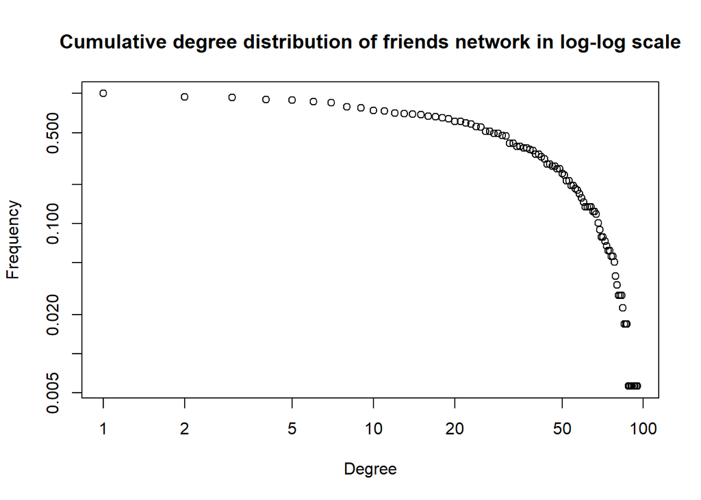

```r
degree_dist <- degree.distribution(friends_graph, cumulative = TRUE)
plot(degree_dist, log="xy", main = "Cumulative degree distribution of friends network in log-log scale", xlab = "Degree", ylab = "Frequency")
```

Is there any correspondence between actual degree distribution of your network and the Power Law distribution? If not, explain why.

Now, let’s see how it would look if it was random. Produce Erdos-Renyi graph matching your real network (same number of nodes and same average degree). Compare it with your degree distribution.

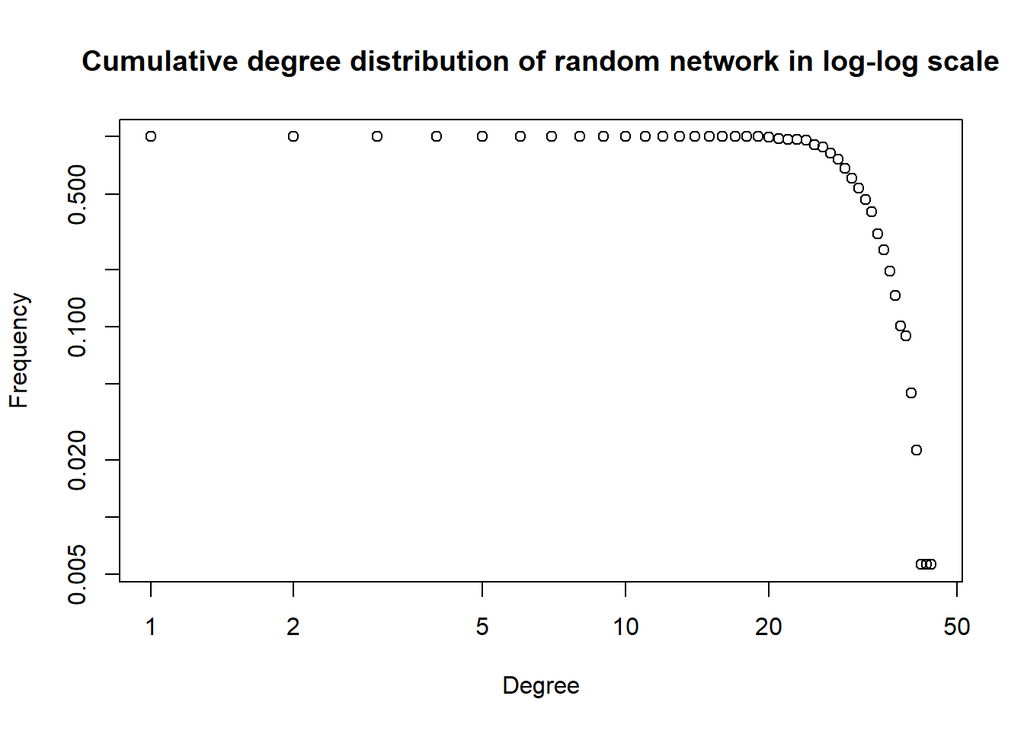

```r
n <- vcount(friends_graph)
mean_degree <- mean(degree(friends_graph))
rndm <- erdos.renyi.game(n, mean_degree/n/2, type = "gnp", directed = TRUE)
rndm_dist <- degree.distribution(rndm, cumulative = TRUE)
plot(rndm_dist, log="xy", main = "Cumulative degree distribution of random network in log-log scale", xlab = "Degree", ylab = "Frequency")
```

### 2. Compute centrality metrics

Compute for your network:

- degree centrality
- closeness centrality
- betweenness centrality
- eigenvector centrality
- Bonacich power centrality
- Alpha centrality

```r
centralization.degree(friends_graph)$centralization
```

```
## [1] 0.1804079
```

```r
centralization.closeness(friends_graph, mode="all")$centralization
```

```
## [1] 0.008855128
```

```r
centralization.betweenness (friends_graph, directed = TRUE, nobigint = TRUE)$centralization
```

```
## [1] 0.2135496
```

```r
centralization.evcent (friends_graph, directed = TRUE, scale = FALSE, options = igraph.arpack.default)$centralization
```

```
## [1] 0.1549212
```

Output six plots corresponding to six centrality metrics you’ve computed:

- Use first names of your friends as node labels on the graph (you may hide this information if you wish – change it by integer ID)
- Keep the same layout of the network
- Make node sizes and colours proportional to the respective centrality metrics

Hint: If you get stuck, lab 4 script might be helpful.

```r
deg<-degree(friends_graph)
lay <- layout.fruchterman.reingold(friends_graph)
fine = 500
palette <- colorRampPalette(c('blue','red'))
degCol <- palette(fine)[as.numeric(cut(deg,breaks = fine))]
vert_size <- ifelse(deg>50, 1/50*deg, 1)
par(mfrow=c(2,3))
plot(friends_graph, layout=lay, vertex.color=degCol, vertex.size=vert_size, vertex.label=NA, edge.width = 0.5, edge.arrow.size = 0.5, main="Degree centrality")

clos=closeness(friends_graph)
closCol = palette(fine)[as.numeric(cut(clos,breaks = fine))]

plot(friends_graph,layout = lay, vertex.label=NA, vertex.color=closCol, vertex.size=clos*15000, edge.width = 0.5, edge.arrow.size = 0.5, main="Closeness centrality")

betw <- betweenness(friends_graph)
betwCol = palette(fine)[as.numeric(cut(betw,breaks = fine))]
vert_size <- ifelse(betw>4000, 1/4000*betw, 1)
plot(friends_graph,layout = lay, vertex.color=betwCol, vertex.size=vert_size, vertex.label=NA, edge.width = 0.5, edge.arrow.size = 0.5, main="Betwenness centrality")

ev <- evcent(friends_graph)$vector
evCol = palette(fine)[as.numeric(cut(ev,breaks = fine))]
vert_size <- ifelse(ev>0.2, 5*ev, 0.8)
plot(friends_graph,layout = lay, vertex.size=vert_size, vertex.color=evCol, vertex.label=NA, edge.width = 0.5, edge.arrow.size = 0.5, main="Eigenvector centrality")

sum(degree(friends_graph) < 3) # if value is non-zero you have isolates
```

```
## [1] 18
```

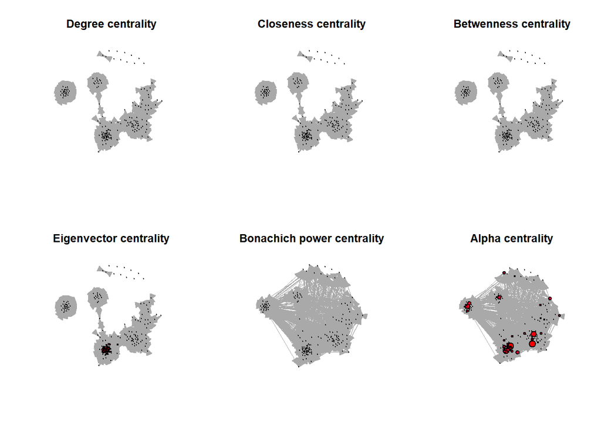

```r
friends_graph_gg <- delete_vertices(friends_graph, which(degree(friends_graph) < 3))

bon <- bonpow(friends_graph_gg, rescale=TRUE)
bonCol = palette(fine)[as.numeric(cut(bon,breaks = fine))]
vert_size <- ifelse(bon>0.01, 5*bon, 0.8)
plot(friends_graph_gg,layout = lay, vertex.size=vert_size, vertex.color=bonCol, vertex.label=NA, edge.width = 0.5, edge.arrow.size = 0.5, main="Bonachich power centrality")
alpha <- alpha.centrality(friends_graph_gg)
alphaCol = palette(fine)[as.numeric(cut(alpha,breaks = fine))]
vert_size <- ifelse(alpha>0.2, 2*alpha, 0.8)
plot(friends_graph_gg,layout = lay, vertex.size=vert_size, vertex.color=alphaCol, vertex.label=NA, edge.width = 0.5, edge.arrow.size = 0.5, main="Alpha centrality")
```

Now, output top ten nodes in each ranking. Again, print only first names in your table to keep privacy:

```r
sort(deg, decreasing = TRUE)[1:10]
```

```
##      tatyana saveleva    yuliya komissarova Ekaterina Guselnikova
##                    94                    86                    86
##      vera chernousova       darya lukyanova      dashenka grekova
##                    83                    82                    79
##       darya shirokova          garik volkov    Elizaveta Kaletina
##                    78                    77                    77
##    Daria Golyzhnikova
##                    76
```

```r
sort(clos, decreasing = TRUE)[1:10]
```

```
##      tatyana saveleva    yuliya komissarova       roman solomatin
##          0.0001382361          0.0001379501          0.0001377980
## Ekaterina Guselnikova       darya lukyanova         anya smirnova
##          0.0001375516          0.0001375138          0.0001374948
##       darya shirokova    Daria Golyzhnikova          garik volkov
##          0.0001374759          0.0001374570          0.0001374382
##     ksyusha zimarkova
##          0.0001372119
```

```r
sort(betw, decreasing = TRUE)[1:10]
```

```
##   tatyana saveleva      anya smirnova dmitrii koshechkin
##          6839.7645          3881.9628          3126.9291
## yuliya komissarova      diana stehova    roman solomatin
##          3061.4027          2600.3374          2405.3140
##          Hua Xiang      aigul ayupova ekaterina bychkova
##          1459.4202          1214.2536          1086.7386
##   elena kolbinceva
##           938.6946
```

```r
sort(ev, decreasing = TRUE)[1:10]
```

```
## Ekaterina Guselnikova      vera chernousova       darya lukyanova
##             1.0000000             0.9996156             0.9624944
##      dashenka grekova    Elizaveta Kaletina          garik volkov
##             0.9516472             0.9485218             0.9420373
##       darya shirokova    Daria Golyzhnikova         inna safarova
##             0.9377003             0.9176317             0.9077200
## anastasiya shevchenko
##             0.8965458
```

*Comment on your results here - for example, why some nodes have high betweenness centrality and the others have high closeness centrality. Is this what you would expect to see?* > Yes, I expected to see something close to that, becouse the result shows several groups of people with which I used to be friends. I lived in 2 cities, have friends from a couple of events not connected to my everyday life or work so it is not a surprice what groups are not highly connected.

## Task 2. Flickr network

In the second task, you will work with a large directed graph.

Please download flickr.mat

*Data contains sparse matrix A and list of user names. This is a denser part of the Flickr photo sharing site friendship graph from 2006. Edge direction corresponds to friendship requests (following). Some of the links are reciprocal, others not*

It’s a Matlab file. How to deal with it in R? There is a package `R.matlab`. Please install it and call `library(R.matlab)`

Now use `readMat` function to read the file and extract adjacency matrix and a list of user names:

```r
flickr <- readMat("flickr.mat")
fmatrix = as.matrix(flickr[1]$A)
fnames = flickr[2]$names
```

If you have trouble loading large mat file on your laptop — try to use HSE computer classes with installed R+RStudio.

Look at user names. You might want to remove spaces from the names. Use a function `gsub` to remove them:

```r
fnames=gsub(" ", "", fnames)
```

Now create a graph, output the number of vertices and edges:

```r
flickr_graph <- graph.adjacency(fmatrix, mode = "directed", weighted = NULL)
vcount(flickr_graph)
```

```
## [1] 15724
```

```r
ecount(flickr_graph)
```

```
## [1] 510983
```

Compute in- and out- degree centralities, PageRank, Hubs and Authorities for this network:

```r
cdi <-centralization.degree(flickr_graph, mode = "in")$centralization

cdo <-centralization.degree(flickr_graph, mode = "out")$centralization

pr <- page.rank(flickr_graph)$vector

h <- hub.score(flickr_graph)$vector

auth <- authority.score(flickr_graph)$vector
```

Print top ten names in each ranking:

```r
deg_in<-degree(flickr_graph, mode = "in")
top_in <- sort(deg_in, decreasing = TRUE)[1:10]
fnames[which(deg_in %in% top_in)]
```

```
##  [1] "notraces"         "awfulsara"        "DrJoanne"
##  [4] "drp"              "BombDog"          ":Nikola"
##  [7] "*Ivan*"           "deborahlattimore" "SimonPais"
## [10] "antimethod"       "MaDGi®L•\231"
```

```r
deg_out=degree(flickr_graph, mode = "out")
top_out <- sort(deg_out, decreasing = TRUE)[1:10]
fnames[which(deg_out %in% top_out)]
```

```
##  [1] "anildash"      "maximolly"     "jakedobkin"    "brainware3000"
##  [5] "Jakes_World"   "Buntekuh"      "pixietart"     "tozzer"
##  [9] "AtiRanA"       "AndreiaLopes"
```

```r
top_pr <- sort(pr, decreasing = TRUE)[1:10]
fnames[which(pr %in% top_pr)]
```

```
##  [1] "awfulsara"        "DrJoanne"         "drp"
##  [4] "BombDog"          "cymagen"          "*Ivan*"
##  [7] "deborahlattimore" "SimonPais"        "antimethod"
## [10] "MaDGi®L•\231"
```

```r
top_hub <- sort(h, decreasing = TRUE)[1:10]
fnames[which(h %in% top_hub)]
```

```
##  [1] "mrpiink"     "noahstone"   "isherwood"   "sgoralnick"  "*starlet*"
##  [6] "automat"     "brynfoto"    "liquidpixel" "lorrainemd"  "schizoo23"
```

```r
top_auth <- sort(auth, decreasing = TRUE)[1:10]
fnames[which(auth %in% top_auth)]
```

```
##  [1] "awfulsara"        "DrJoanne"         "drp"
##  [4] "BombDog"          ":Nikola"          "cymagen"
##  [7] "*Ivan*"           "deborahlattimore" "SimonPais"
## [10] "antimethod"
```

Produce the following plots:

- In-degree centralities versus out-degree centralities
- In-degree centralities versus authorities
- Out-degree centralities versus hubs
- Hubs versus authorities
- PageRank versus hubs
- PageRank versus authorities

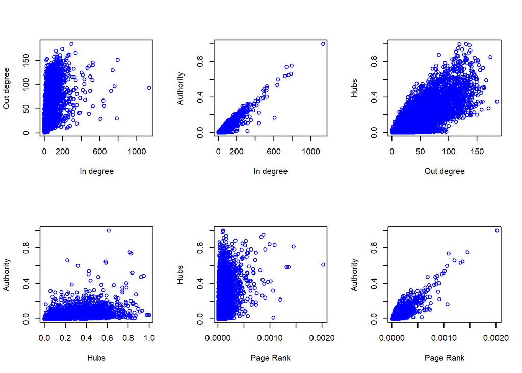

```r
par(mfrow = c(2, 3))
plot(deg_in, deg_out, col="blue", xlab = "In degree", ylab = "Out degree")
plot(deg_in, auth, col="blue", xlab = "In degree", ylab = "Authority")
plot(deg_out, h, col="blue", xlab = "Out degree", ylab = "Hubs")
plot(h, auth, col="blue", xlab = "Hubs", ylab = "Authority")
plot(pr, h, col="blue", xlab = "Page Rank", ylab = "Hubs")
plot(pr, auth, col="blue", xlab = "Page Rank", ylab = "Authority")
```

*Comment on the relationships between different centrality metrics*

Hubs and outdegree connected, but with a fact of zero hubs for some big values of outdegree, because of the trendings in outdegree - the stats of outdegree are collected and used for recommendations.

Authority and hubs are not connected (the average value of Authority is close to zero) because the queries can contain different info than the pages really have.

Hubs is also not about page rank, so it’s also bad correlation.

Authority and page rank closely connected, because both Authority and page rank are oriented on out- and in- degree connection.